# Results: Type-I Error Simulation

Visualizations of the results can be found here: [Tableau Dashboard](https://public.tableau.com/profile/richard2368#!/vizhome/ThesisVisualizations/PowerType-IErrorAcrossSampleSizesDashboard)

The purpose of this report is to outline in detail the analysis procedure used to generate the results when the null hypothesis is true. The outcome measures include:

1. Type-I error rate
2. Experimental and control means
3. Experimental and control standard deviations

The large amount of data makes it challenging to understand because there would be too many visualizations to look through. For this reason the table will be exported and a Tableau dashboard will be created to enable quick filtering and comparisons.

### Using the “here” package

```r
# install.packages("here")
library(here)
library(xtable)
here("pre proposal rejection")

load(here("pre proposal rejection", "Type_I_Error_Simulation_Data.RData"))
```

### Begin by loading in all of the packages and libraries

```r
#Packages and Libraries needed to run the code

#install.packages("XLConnect")
#install.packages("data.table")
#install.packages("gdata")
#install.packages("markdown")
#install.packages("xlsx")
#install.packages("car")
#install.packages("lmerTest")
#install.packages("MESS")
#install.packages("pracma")
#install.packages("fBasics")
#install.packages("corrr")
# install.packages("lsr")
# install.packages("lme4")
# install.packages('dplyr')
# install.packages("pwr2")
# install.packages("agricolae")
# install.packages("multcomp")
# install.packages("lsmeans")
library(multcomp)
library(lsmeans)
library(agricolae)
# library(pwr2)
library(lme4)
# library(pwr)
library(gridExtra)
# library(lsr)
# library(tidyr)
library(reshape2)
# library(pracma)
# library(MESS)
library(data.table)
library(lmerTest)
library(car)
library(ggplot2)
# library(XLConnect)
library(gdata)
library(markdown)
library(xlsx)
library(dplyr)
library(plyr)
library(gtools)
library(dplyr)
library(boot)
library(broom)
library(knitr)
options(scipen=999) #stopping scientific notation
```

### List all of the paths and common variables needed for the analysis

```r
###COMMON VARIABLE USED IN ALL SIMULATIONS


path = "Y:/Archived Studies/Richard - 10-2018/Code/Kits EEG Data/Simulation/"

output_path = "C:/Users/rjobrien/Desktop/Thesis Code/Output/"

plot_path = "Y:/Archived Studies/Richard - 10-2018/Code/Kits EEG Data/Simulation/Plots/"
```

### Functions

```r
#Function for performing anova model for each peak-picking methodology
methodology_anova = function(data, methodology){
  model_data = anova(lm(PZ ~ condition, data[data$method == methodology,]))
  model_data = model_data[1,]
  model_data[, 6] = s #sample size
  model_data[, 7] = e #effect size
  model_data[, 8] = i #simulation number
  model_data[, 9] = paste0(methodology, "Methodology")
}
```

### Simulation Procedure Type-I Error

#### Dataset production

1. Using the sample size, randomly subset samples (ERP waveforms) from the population dataset. The subset of the data drawn from the population dataset without replacement is twice the sample size selected.
2. To create the control condition, randomly subset a number of samples from the subsetted data set equal to the sample size.
3. To create the experimental conditions data set, remove the control conditions data from the subsetted dataset to leave the remaining samples
4. Subsetting out the time window (300-500 ms) in which we believe the P3 amplitude will fall within

#### Combining all of the peak-picking methodologies data together into one large dataframe

8. Label and combine all of the peak-picking methodologies data together

#### Means

9. Calculating means of each peak-picking methodology by condition and generating a new dataset

#### Conducting an ANOVAs

10. Perform an ANOVA with the P3 amplitude as a dependent variable and fixed effects with condition and peak-picking methodology
11. Performing an ANOVA for each peak-picking methodology with the P3 amplitude as a dependent variable and a fixed effect of condition. Store the p-values in a new dataframe, and use these values later to calculate the type-I error rate.

#### Post-Hoc testing

12. Perform a Tukey’s HSD post-hoc test on the anova model with the condition and peak-picking methodology fixed effects
13. Generate a new dataset containing the p-values from the Tukey HSD post-hoc test

#### Calculate the type-I error rate

14. Calculate the type-I error rate.

```r
set.seed(1234)

peak_pvalue_dist = data.frame()

simulation_number = 1000
numTests <- simulation_number  #number of t-test
alphaSet = c(0.05)  #set of alpha values to test
sigTests <- data.frame()
pvalue_dist = data.frame()
allmeans = data.frame()
post_hoc_results_temp1 = data.frame()
post_hoc_results_temp2 = data.frame()
post_hoc_results_condition = data.frame()
post_hoc_results_method = data.frame()
all.peak.result = data.frame()
all.mean.result = data.frame()
all.adaptive.mean.result = data.frame()


sample_size = unlist(seq(10, 100, 10))

effect_size = 0


for (s in sample_size){


  for (e in effect_size){

    #Starting the simulation
    counter <- 1 #keeps track of row numbers in the output table
    for (i in 1:numTests) {


        #======================================================================================#
        #Building the experimental and control conditions datasets
        #======================================================================================#

        #Sample the necessary number of sample from the popultion dataset (2 times: one for each condition)
        temp = ERP2_PZ[ERP2_PZ$sample %in% sample(unique(ERP2_PZ$sample),
                                        size = s * 2,
                                        replace = FALSE), ]

        unique(temp$sample)#Checking to see if we subsetted 80 unique samples
        # length(unique(temp$sample))

        #Then randomly sample the control condition from the temp data
        control_condition = temp[temp$sample %in% sample(unique(temp$sample),
                                                size = s,
                                                replace = FALSE), ]

        #Checking to see if we subsetted half the number unique samples from temp
        # length(unique(control_condition$sample))

        control_condition$condition = "control"

        #Remove those samples from the original dataset, and the remaining trials become the experimental condition
        experimental_condition = temp[!temp$sample %in% control_condition$sample, ]

        #Checking to see if we remove the unique samples used for the control condition
        length(unique(experimental_condition$sample))

        experimental_condition$condition = "experimental"

        #Combining the experimental and control conditions together
        conditions_combined = rbind(experimental_condition, control_condition)


        #======================================================================================#
        #Subsetting out the time window of interest to represent the P3 amplitude
        #======================================================================================#


        #Subsetting out the time window we expect the P3 to fall within
        data = conditions_combined[(conditions_combined$TIME >= 300 &
                                               conditions_combined$TIME <= 500),]


        #======================================================================================#
        #Generating peak amplitudes
        #======================================================================================#
        #Calculating the peak amplitude
        peak_amps_erp = setDT(data)[, .SD[which.max(PZ)], by = list(sample, condition)]

        peak_amps_erp = peak_amps_erp[, c("sample", "condition", "PZ")]

        peak_amps_erp$method = "Peak Amplitude"


        #======================================================================================#
        #Calculating the adaptive mean amplitude
        #======================================================================================#

        #This way seems to work if you want to use more than one index
        mean_amps_erp1 = rbind(setDT(data)[, .SD[c(which.max(PZ) - 1)], by = list(sample, condition)],
                               setDT(data)[, .SD[c(which.max(PZ) - 2)], by = list(sample, condition)],
                               setDT(data)[, .SD[c(which.max(PZ) - 3)], by = list(sample, condition)],
                               setDT(data)[, .SD[c(which.max(PZ) - 4)], by = list(sample, condition)])


        mean_amps_erp = setDT(data)[, .SD[c(
                                       which.max(PZ),
                                       which.max(PZ) + 1,
                                       which.max(PZ) + 2,
                                       which.max(PZ) + 3,
                                       which.max(PZ) + 4
                                       )],
                                    by = list(sample, condition)]

        mean_amps_erp = na.omit(rbind(mean_amps_erp, mean_amps_erp1))

        mean_amps_erp = mean_amps_erp[, c("sample", "condition", "PZ")]

        mean_amps_erp = setDT(mean_amps_erp)[ , mean(PZ), by = list(sample, condition)]

        colnames(mean_amps_erp) = c("sample", "condition", "PZ")

        mean_amps_erp$method = "Adaptive Mean Amplitude"

        #======================================================================================#
        #Calculating the mean amplitude
        #======================================================================================#

        mean2_amps_erp = aggregate(. ~ sample + condition, data, FUN = mean)

        mean2_amps_erp = na.omit(mean2_amps_erp)

        mean2_amps_erp = mean2_amps_erp[, c("sample", "condition", "PZ")]

        mean2_amps_erp$method = "Mean Amplitude"


        #======================================================================================#
        #Combined all 3 datasets together
        #======================================================================================#

        peak_methods = rbind(peak_amps_erp, mean_amps_erp, mean2_amps_erp)


        #======================================================================================#
        #Calculating means of each peak-picking methodology by condition
        #======================================================================================#

        means = aggregate(PZ ~ condition + method, peak_methods, FUN = mean)
        means[, 4] = s #sample size
        means[, 5] = e #effect size
        means[, 6] = i #simulation number

        allmeans = rbind(allmeans, means)


        #======================================================================================#
        #Calculating the p-values for the anova
        #======================================================================================#
        #Running a linear regression with an interation between condition and method
        test.result = anova(lm(PZ ~ condition + method, peak_methods))

        #Running an ANOVA and putting together all of the data into a dataframe
        sigTests[counter, 1] = test.result$'Pr(>F)'[1] #main effect of condition
        sigTests[counter, 2] = test.result$'Pr(>F)'[2] #main effect of method
        sigTests[counter, 4] = s #sample size
        sigTests[counter, 5] = e #effect size
        sigTests[counter, 6] = i #simulation number


        #======================================================================================#
        #Calculating the p-values for each methodology to see if there's a condition effect
        #======================================================================================#

        #Anova peak amplitude by condition
        peak.result = methodology_anova(peak_methods, "Peak Amplitude")

        #Anova adaptive mean amplitude by condition
        adaptive.mean.result = methodology_anova(peak_methods, "Adaptive Mean Amplitude")

        #Anova mean amplitude by condition
        mean.result = methodology_anova(peak_methods, "Mean Amplitude")


        #Rbinding to larger dataframe
        all.peak.result = rbind(all.peak.result, peak.result)
        all.adaptive.mean.result = rbind(all.adaptive.mean.result, adaptive.mean.result)
        all.mean.result = rbind(all.mean.result, mean.result)


        #======================================================================================#
        #Calculating the p-values for the post-hoc test
        #======================================================================================#
        post_hoc_results = TukeyHSD(aov(PZ ~ condition + method, peak_methods)) #Confidence level is 95%

        post_hoc_results_temp1 = as.data.frame(post_hoc_results[1])
        post_hoc_results_temp1[, 5] = s #sample size
        post_hoc_results_temp1[, 6] = e #effect size
        post_hoc_results_temp1[, 7] = i #simulation number

        post_hoc_results_temp2 = as.data.frame(post_hoc_results[2])
        post_hoc_results_temp2[, 5] = s #sample size
        post_hoc_results_temp2[, 6] = e #effect size
        post_hoc_results_temp2[, 7] = i #simulation number


        post_hoc_results_condition = rbind(post_hoc_results_condition, post_hoc_results_temp1)
        post_hoc_results_method = rbind(post_hoc_results_method, post_hoc_results_temp2)

        counter <- counter + 1 #move to the next row
    }

    pvalue_dist = rbind(pvalue_dist, sigTests)

  }
}

#======================================================================================#
#Setting column names
#======================================================================================#
colnames(pvalue_dist)[1:6] = c("condition", "method", "condition*method", "sample_size", "effect_size", "sample")
colnames(allmeans)[4:6] = c("sample_size", "effect_size", "sample")
colnames(post_hoc_results_method)[5:7] = c("sample_size", "effect_size", "sample")
colnames(post_hoc_results_condition)[5:7] = c("sample_size", "effect_size", "sample")
colnames(all.peak.result)[6:9] = c("sample_size", "effect_size", "sample", "method")
colnames(all.adaptive.mean.result)[6:9] = c("sample_size", "effect_size", "sample", "method")
colnames(all.mean.result)[6:9] = c("sample_size", "effect_size", "sample", "method")


#======================================================================================#
#Converting the method into a column and removing unnecessary numeric values
#======================================================================================#
post_hoc_results_method$method = gsub('[[:digit:]]+', "", rownames(post_hoc_results_method))
rownames(post_hoc_results_method) = NULL

post_hoc_results_condition$condition = gsub('[[:digit:]]+', "", rownames(post_hoc_results_condition))
rownames(post_hoc_results_condition) = NULL

# pvalue_dist$condition_typeIerror = ifelse(pvalue_dist$condition < 0.05, 1, 0)
# pvalue_dist2 = aggregate(. ~ sample_size, pvalue_dist, FUN = sum)

#======================================================================================#
#Combining the individual method results together - need this to find the type-I error
#======================================================================================#
all.results = rbind(all.peak.result, all.adaptive.mean.result, all.mean.result)

#======================================================================================#
#Finding the type I error
#======================================================================================#
all.results$typeIerror = ifelse(all.results$`Pr(>F)` <= 0.05, 1, 0)
all.results2 = aggregate(. ~ sample_size + effect_size + method, all.results, FUN = sum)
all.results2$typeIerror = (all.results2$typeIerror/numTests)*100
```

### POST-HOC SUMMARY TABLE

```r
summary_post_hoc_results_method = post_hoc_results_method

summary_post_hoc_results_method = aggregate(. ~ sample_size + effect_size + method,
                                            summary_post_hoc_results_method, FUN = mean)
```

### GENERATING A TABLE CONTAINING ALL RESULTS

```r
table3 = all.results2[, c("method", "sample_size", "effect_size", "typeIerror")]


#COMBINE TABLE 3 WITH THE MEANS AND STANDARD DEVIATIONS
one_table = merge(dcast(allmeans, method + sample_size + effect_size ~ condition, fun = mean, value.var = "PZ"),
                  dcast(allmeans, method + sample_size + effect_size ~ condition, fun = sd, value.var = "PZ"),
                  by = c("method", "sample_size", "effect_size"))

#Changing the column names
colnames(one_table) = c("method",
                        "sample_size",
                        "effect_size",
                        "control_means",
                        "experimental_means",
                        "control_sd",
                        "experimental_sd")

#THIS MAY NOT BE NEEDED IN THE FUTURE
table3$method = as.factor(table3$method)
levels(table3$method) = c("Adaptive Mean Amplitude", "Mean Amplitude", "Peak Amplitude")

one_table = merge(one_table, table3, by = c("method", "sample_size", "effect_size"))

#Sorting the data
one_table = one_table[order(one_table$method, one_table$sample_size), ]

kable(one_table)
```

|  | method | sample_size | effect_size | control_means | experimental_means | control_sd | experimental_sd | typeIerror |
| --- | --- | --- | --- | --- | --- | --- | --- | --- |
| 1 | Adaptive Mean Amplitude | 10 | 0 | 9.424928 | 9.415139 | 1.1568654 | 1.1036362 | 5.3 |
| 3 | Adaptive Mean Amplitude | 20 | 0 | 9.404058 | 9.387577 | 0.7983441 | 0.7858536 | 5.5 |
| 4 | Adaptive Mean Amplitude | 30 | 0 | 9.380657 | 9.362240 | 0.6407171 | 0.6219119 | 4.8 |
| 5 | Adaptive Mean Amplitude | 40 | 0 | 9.400372 | 9.416410 | 0.5241227 | 0.5289432 | 5.2 |
| 6 | Adaptive Mean Amplitude | 50 | 0 | 9.414859 | 9.404253 | 0.4651802 | 0.4711904 | 5.4 |
| 7 | Adaptive Mean Amplitude | 60 | 0 | 9.401882 | 9.400878 | 0.4121606 | 0.4081271 | 5.1 |
| 8 | Adaptive Mean Amplitude | 70 | 0 | 9.407473 | 9.383976 | 0.3607799 | 0.3722105 | 4.9 |
| 9 | Adaptive Mean Amplitude | 80 | 0 | 9.379487 | 9.432182 | 0.3252985 | 0.3357394 | 4.8 |
| 10 | Adaptive Mean Amplitude | 90 | 0 | 9.400031 | 9.401920 | 0.3113942 | 0.2912790 | 5.8 |
| 2 | Adaptive Mean Amplitude | 100 | 0 | 9.409768 | 9.405944 | 0.2728172 | 0.2694092 | 4.4 |
| 11 | Mean Amplitude | 10 | 0 | 6.364421 | 6.335450 | 0.9104669 | 0.8687205 | 5.1 |
| 13 | Mean Amplitude | 20 | 0 | 6.327397 | 6.308645 | 0.6286688 | 0.5992998 | 5.0 |
| 14 | Mean Amplitude | 30 | 0 | 6.309064 | 6.302443 | 0.4881906 | 0.4864269 | 5.3 |
| 15 | Mean Amplitude | 40 | 0 | 6.325451 | 6.331390 | 0.4103081 | 0.4109685 | 5.5 |
| 16 | Mean Amplitude | 50 | 0 | 6.329215 | 6.332954 | 0.3647133 | 0.3702771 | 5.8 |
| 17 | Mean Amplitude | 60 | 0 | 6.319011 | 6.330302 | 0.3124064 | 0.3146028 | 4.5 |
| 18 | Mean Amplitude | 70 | 0 | 6.336757 | 6.315004 | 0.2816315 | 0.2924999 | 5.0 |
| 19 | Mean Amplitude | 80 | 0 | 6.312776 | 6.342229 | 0.2540959 | 0.2614837 | 5.3 |
| 20 | Mean Amplitude | 90 | 0 | 6.324922 | 6.326874 | 0.2419793 | 0.2295482 | 5.8 |
| 12 | Mean Amplitude | 100 | 0 | 6.329141 | 6.332929 | 0.2088882 | 0.2080330 | 4.2 |
| 21 | Peak Amplitude | 10 | 0 | 10.565550 | 10.552888 | 1.1741726 | 1.1345389 | 4.5 |
| 23 | Peak Amplitude | 20 | 0 | 10.530870 | 10.499648 | 0.8131711 | 0.7947632 | 5.5 |
| 24 | Peak Amplitude | 30 | 0 | 10.506004 | 10.495715 | 0.6545289 | 0.6387510 | 5.1 |
| 25 | Peak Amplitude | 40 | 0 | 10.524545 | 10.544735 | 0.5284204 | 0.5353557 | 4.9 |
| 26 | Peak Amplitude | 50 | 0 | 10.545767 | 10.526059 | 0.4764984 | 0.4817251 | 5.5 |
| 27 | Peak Amplitude | 60 | 0 | 10.520760 | 10.525773 | 0.4174024 | 0.4134210 | 5.5 |
| 28 | Peak Amplitude | 70 | 0 | 10.533629 | 10.506393 | 0.3643122 | 0.3828016 | 5.2 |
| 29 | Peak Amplitude | 80 | 0 | 10.508037 | 10.557154 | 0.3283359 | 0.3405117 | 4.7 |
| 30 | Peak Amplitude | 90 | 0 | 10.527912 | 10.523324 | 0.3150280 | 0.2938754 | 5.4 |
| 22 | Peak Amplitude | 100 | 0 | 10.531951 | 10.532877 | 0.2780530 | 0.2767344 | 4.1 |

# Analyzing the Means

## MEAN - ANOVA

We wouldn’t anticipate that there would be an interaction between sample size and method, so we’d want to use a type II anova.

```r
#=========================================#
#PREPARING DATASET
#=========================================#
#Determining whether the type-I error rate is different across sample size, effect size, and methodology

#Converting to a factor. This need to be a factor for the ANOVA degrees of freedom to be correct
allmeans[, c("sample_size", "effect_size")] = lapply(allmeans[, c("sample_size", "effect_size")], function(x) factor(x))


#=========================================#
#CONDUCTING AN ANOVA AND CHECKING DIFFERENCES BETWEEN TYPES
#=========================================#
#Effect size doesn't need to be included because it contains a single category
model = lm(PZ ~ sample_size + method + condition, allmeans)

kable(Anova(model, type = "II"), caption = "Anova Type II SS", digits = 4)
```

Anova Type II SS

|  | Sum Sq | Df | F value | Pr(>F) |
| --- | --- | --- | --- | --- |
| sample_size | 8.9401 | 9 | 3.3358 | 0.0004 |
| method | 189154.3997 | 2 | 317600.5906 | 0.0000 |
| condition | 0.0670 | 1 | 0.2249 | 0.6353 |
| Residuals | 17863.3247 | 59987 | NA | NA |

```r
#In case I need to report the interaction
model = lm(PZ ~ sample_size * method * condition, allmeans)

kable(Anova(model, type = "III"), caption = "Anova Type III SS", digits = 4)
```

Anova Type III SS

|  | Sum Sq | Df | F value | Pr(>F) |
| --- | --- | --- | --- | --- |
| (Intercept) | 88829.2596 | 1 | 298174.8976 | 0.0000 |
| sample_size | 1.7532 | 9 | 0.6539 | 0.7514 |
| method | 9439.0673 | 2 | 15842.1501 | 0.0000 |
| condition | 0.0479 | 1 | 0.1608 | 0.6884 |
| sample_size:method | 0.3806 | 18 | 0.0710 | 1.0000 |
| sample_size:condition | 2.2037 | 9 | 0.8219 | 0.5958 |
| method:condition | 0.1070 | 2 | 0.1796 | 0.8356 |
| sample_size:method:condition | 0.6234 | 18 | 0.1162 | 1.0000 |
| Residuals | 17856.7205 | 59940 | NA | NA |

Outcomes:

- Main effect of method
- Main effect of sample size
- No main effect of condition

## MEAN - POST-HOC SAMPLE SIZE

```r
#Post-hoc test with just sample size comparisons
#Any statistically significant differences here don't really make sense and might be occurring by chance
post_hoc_model1 = emmeans(
  lm(PZ ~ sample_size + method, allmeans),
  pairwise ~ sample_size,
  adjust = "tukey",
  mode = "satterthwaite"
  ) %>%
  summary(infer = TRUE)

kable(post_hoc_model1[2], #Printing only the comparisons
caption = "Post-Hoc Sample Size Comparisons"
)
```

Post-Hoc Sample Size Comparisons

| contrast | estimate | SE | df | lower.CL | upper.CL | t.ratio | p.value |
| --- | --- | --- | --- | --- | --- | --- | --- |
| 10 - 20 | 0.0333632 | 0.009963 | 59988 | 0.0018435 | 0.0648829 | 3.3487206 | 0.0279649 |
| 10 - 30 | 0.0503754 | 0.009963 | 59988 | 0.0188557 | 0.0818951 | 5.0562574 | 0.0000189 |
| 10 - 40 | 0.0192453 | 0.009963 | 59988 | -0.0122744 | 0.0507650 | 1.9316806 | 0.6472459 |
| 10 - 50 | 0.0175447 | 0.009963 | 59988 | -0.0139750 | 0.0490644 | 1.7609891 | 0.7598611 |
| 10 - 60 | 0.0266282 | 0.009963 | 59988 | -0.0048916 | 0.0581479 | 2.6727101 | 0.1847417 |
| 10 - 70 | 0.0291907 | 0.009963 | 59988 | -0.0023291 | 0.0607104 | 2.9299126 | 0.0973538 |
| 10 - 80 | 0.0210850 | 0.009963 | 59988 | -0.0104347 | 0.0526047 | 2.1163378 | 0.5157393 |
| 10 - 90 | 0.0255653 | 0.009963 | 59988 | -0.0059544 | 0.0570850 | 2.5660280 | 0.2338793 |
| 10 - 100 | 0.0192944 | 0.009963 | 59988 | -0.0122253 | 0.0508141 | 1.9366066 | 0.6438083 |
| 20 - 30 | 0.0170122 | 0.009963 | 59988 | -0.0145076 | 0.0485319 | 1.7075368 | 0.7915735 |
| 20 - 40 | -0.0141179 | 0.009963 | 59988 | -0.0456376 | 0.0174018 | -1.4170400 | 0.9223126 |
| 20 - 50 | -0.0158185 | 0.009963 | 59988 | -0.0473382 | 0.0157012 | -1.5877315 | 0.8545060 |
| 20 - 60 | -0.0067351 | 0.009963 | 59988 | -0.0382548 | 0.0247846 | -0.6760105 | 0.9996399 |
| 20 - 70 | -0.0041726 | 0.009963 | 59988 | -0.0356923 | 0.0273471 | -0.4188080 | 0.9999938 |
| 20 - 80 | -0.0122782 | 0.009963 | 59988 | -0.0437979 | 0.0192415 | -1.2323828 | 0.9672963 |
| 20 - 90 | -0.0077979 | 0.009963 | 59988 | -0.0393177 | 0.0237218 | -0.7826926 | 0.9988240 |
| 20 - 100 | -0.0140689 | 0.009963 | 59988 | -0.0455886 | 0.0174508 | -1.4121140 | 0.9238794 |
| 30 - 40 | -0.0311301 | 0.009963 | 59988 | -0.0626498 | 0.0003896 | -3.1245767 | 0.0561968 |
| 30 - 50 | -0.0328307 | 0.009963 | 59988 | -0.0643504 | -0.0013110 | -3.2952683 | 0.0332326 |
| 30 - 60 | -0.0237472 | 0.009963 | 59988 | -0.0552669 | 0.0077725 | -2.3835473 | 0.3356122 |
| 30 - 70 | -0.0211847 | 0.009963 | 59988 | -0.0527044 | 0.0103350 | -2.1263448 | 0.5086022 |
| 30 - 80 | -0.0292904 | 0.009963 | 59988 | -0.0608101 | 0.0022294 | -2.9399196 | 0.0947681 |
| 30 - 90 | -0.0248101 | 0.009963 | 59988 | -0.0563298 | 0.0067096 | -2.4902294 | 0.2735201 |
| 30 - 100 | -0.0310810 | 0.009963 | 59988 | -0.0626007 | 0.0004387 | -3.1196508 | 0.0570213 |
| 40 - 50 | -0.0017006 | 0.009963 | 59988 | -0.0332203 | 0.0298191 | -0.1706916 | 1.0000000 |
| 40 - 60 | 0.0073829 | 0.009963 | 59988 | -0.0241368 | 0.0389026 | 0.7410295 | 0.9992406 |
| 40 - 70 | 0.0099454 | 0.009963 | 59988 | -0.0215743 | 0.0414651 | 0.9982319 | 0.9924346 |
| 40 - 80 | 0.0018397 | 0.009963 | 59988 | -0.0296800 | 0.0333594 | 0.1846572 | 1.0000000 |
| 40 - 90 | 0.0063200 | 0.009963 | 59988 | -0.0251997 | 0.0378397 | 0.6343473 | 0.9997869 |
| 40 - 100 | 0.0000491 | 0.009963 | 59988 | -0.0314706 | 0.0315688 | 0.0049259 | 1.0000000 |
| 50 - 60 | 0.0090835 | 0.009963 | 59988 | -0.0224363 | 0.0406032 | 0.9117210 | 0.9961512 |
| 50 - 70 | 0.0116460 | 0.009963 | 59988 | -0.0198738 | 0.0431657 | 1.1689235 | 0.9769811 |
| 50 - 80 | 0.0035403 | 0.009963 | 59988 | -0.0279794 | 0.0350600 | 0.3553487 | 0.9999985 |
| 50 - 90 | 0.0080206 | 0.009963 | 59988 | -0.0234991 | 0.0395403 | 0.8050389 | 0.9985306 |
| 50 - 100 | 0.0017497 | 0.009963 | 59988 | -0.0297700 | 0.0332694 | 0.1756175 | 1.0000000 |
| 60 - 70 | 0.0025625 | 0.009963 | 59988 | -0.0289572 | 0.0340822 | 0.2572024 | 0.9999999 |
| 60 - 80 | -0.0055431 | 0.009963 | 59988 | -0.0370628 | 0.0259766 | -0.5563723 | 0.9999290 |
| 60 - 90 | -0.0010629 | 0.009963 | 59988 | -0.0325826 | 0.0304568 | -0.1066821 | 1.0000000 |
| 60 - 100 | -0.0073338 | 0.009963 | 59988 | -0.0388535 | 0.0241859 | -0.7361036 | 0.9992803 |
| 70 - 80 | -0.0081056 | 0.009963 | 59988 | -0.0396253 | 0.0234141 | -0.8135748 | 0.9984035 |
| 70 - 90 | -0.0036254 | 0.009963 | 59988 | -0.0351451 | 0.0278943 | -0.3638846 | 0.9999982 |
| 70 - 100 | -0.0098963 | 0.009963 | 59988 | -0.0414160 | 0.0216234 | -0.9933060 | 0.9927040 |
| 80 - 90 | 0.0044803 | 0.009963 | 59988 | -0.0270395 | 0.0360000 | 0.4496902 | 0.9999885 |
| 80 - 100 | -0.0017907 | 0.009963 | 59988 | -0.0333104 | 0.0297291 | -0.1797313 | 1.0000000 |
| 90 - 100 | -0.0062709 | 0.009963 | 59988 | -0.0377906 | 0.0252488 | -0.6294214 | 0.9998003 |

## MEAN - POST-HOC METHODOLOGY

```r
#Post-hoc test with just sample size comparisons
#Any statistically significant differences here don't really make sense and might be occurring by chance
post_hoc_model2 = emmeans(
  lm(PZ ~ sample_size + method, allmeans),
  pairwise ~ method,
  adjust = "tukey",
  mode = "satterthwaite"
  ) %>%
  summary(infer = TRUE)

kable(post_hoc_model2[2], #Printing only the comparisons
caption = "Post-Hoc Methodology Comparisons"
)
```

Post-Hoc Methodology Comparisons

| contrast | estimate | SE | df | lower.CL | upper.CL | t.ratio | p.value |
| --- | --- | --- | --- | --- | --- | --- | --- |
| Adaptive Mean Amplitude - Mean Amplitude | 3.074883 | 0.0054569 | 59988 | 3.062094 | 3.087673 | 563.4804 | 0 |
| Adaptive Mean Amplitude - Peak Amplitude | -1.126278 | 0.0054569 | 59988 | -1.139067 | -1.113488 | -206.3934 | 0 |
| Mean Amplitude - Peak Amplitude | -4.201161 | 0.0054569 | 59988 | -4.213950 | -4.188371 | -769.8738 | 0 |

- I think it’s suggesting a main effect of sample size because as the sample sizes become larger the variability becomes smaller and smaller, leading to a significant difference. The means otherwise are not far apart.
- The number of sample size comparisons that are significantly different are quite small. this doesn’t seem relevant considering the means of the across sample sizes are virtually the same.

## MEAN - POST-HOC VISUALIZATIONS

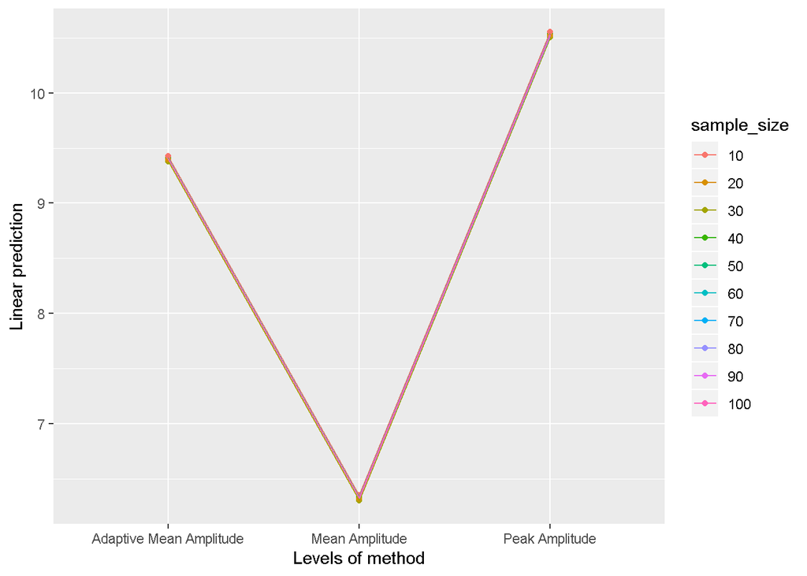

```r
#=========================================#
#POST-HOC TUKEY TESTS AND VISUALIZATIONS
#=========================================#
#This graph indicates that all sample sizes produce similar results for each peak-picking methodology
emmip(lm(PZ ~ sample_size + method, allmeans), sample_size ~ method)
```

- This graph indicates that all sample sizes produce similar results for each peak-picking methodology

# Analyzing the Type-I Error Rate

## MEAN - TYPE-I ERROR

```r
#=========================================#
#PREPARING DATASET
#=========================================#
#Determining whether the type-I error rate is different across sample size, effect size, and methodology

#Converting to a factor. This need to be a factor for the ANOVA degrees of freedom to be correct
all.results[, c("sample_size", "effect_size")] = lapply(all.results[, c("sample_size", "effect_size")], function(x) factor(x))


#=========================================#
#CONDUCTING AN ANOVA AND CHECKING DIFFERENCES BETWEEN TYPES
#=========================================#
#Effect size doesn't need to be included because it contains a single category. A type "II" SS ANOVA was chosen because we didn't expect an interaction between sample size and methodology
model2 = lm(`Pr(>F)` ~ sample_size + method, all.results)

kable(Anova(model2, type = "II"), caption = "Anova Type II SS", digits = 4)
```

Anova Type II SS

|  | Sum Sq | Df | F value | Pr(>F) |
| --- | --- | --- | --- | --- |
| sample_size | 1.3580 | 9 | 1.7985 | 0.0631 |
| method | 0.0307 | 2 | 0.1832 | 0.8326 |
| Residuals | 2515.8112 | 29988 | NA | NA |

```r
#For the sake of comparison we can run the model again with an interaction term and a type "III" SS

kable(Anova(lm(`Pr(>F)` ~ sample_size * method, all.results), type = "III"), caption = "Anova Type III SS", digits = 4)
```

Anova Type III SS

|  | Sum Sq | Df | F value | Pr(>F) |
| --- | --- | --- | --- | --- |
| (Intercept) | 254.7967 | 1 | 3035.5902 | 0.0000 |
| sample_size | 0.4048 | 9 | 0.5359 | 0.8495 |
| method | 0.0204 | 2 | 0.1215 | 0.8856 |
| sample_size:method | 0.2353 | 18 | 0.1557 | 1.0000 |
| Residuals | 2515.5759 | 29970 | NA | NA |

Outcomes:

- No main effect of sample size
- No main effect of methodology
- These results align with what we’d expect to see based on the graph in Tableau

## Conclusions

#### Writing result tables to word APA style

```r
# rmarkdown::render(paste0(
#       here::here("pre proposal rejection"),
#       "1-Type_I_Error_Simulation_Statistics_Report.Rmd"
#     ))
```